# BELLEBEAT CAPTONE PROJECT

Kolawole Olaitan Adeola

2024-07-15

##1.0 INTRODUCTION

ABOUT THE COMPANY

Urška Sršen and Sando Mur founded Bellabeat, a high-tech company that manufactures health-focused smart products. Sršen used her background as an artist to develop beautifully designed technology that informs and inspires women around the world. Collecting data on activity, sleep, stress, and reproductive health has allowed Bellabeat to empower women with knowledge about their own health and habits. Since it was founded in 2013, Bellabeat has grown rapidly and quickly positioned itself as a tech-driven wellness company for women.

By 2016, Bellabeat had opened offices around the world and launched multiple products. Bellabeat products became available through a growing number of online retailers in addition to their own e-commerce channel on their website. The company has invested in traditional advertising media, such as radio, out-of-home billboards, print, and television, but focuses on digital marketing extensively. Bellabeat invests year-round in Google Search, maintaining active Facebook and Instagram pages, and consistently engages consumers on Twitter. Additionally, Bellabeat runs video ads on Youtube and display ads on the Google Display Network to support campaigns around key marketing dates.

## BUSINESS TASK

Sršen asks to analyze smart device usage data in order to gain insight into how consumers use non-Bellabeat smart devices.

## BUSINESS QUESTIONS:

*1. What are some trends in smart device usage?* 2. How could these trends apply to Bellabeat customers? *3. How could these trends help influence Bellabeat marketing strategy?

##2.0 PREPARATION

Sršen encourages you to use public data that explores smart device users’ daily habits. She points you to a specific data set: ● FitBit Fitness Tracker Data (CC0: Public Domain, dataset made available through Mobius): This Kaggle data set contains personal fitness tracker from thirty fitbit users. Thirty eligible Fitbit users consented to the submission of personal tracker data, including minute-level output for physical activity, heart rate, and sleep monitoring. It includes information about daily activity, steps, and heart rate that can be used to explore users’ habits. The public data contains over 10 files of users and rows containing observation of each day of each users. The dataset is limited to only 33 users which is condisered standard for analysis,in other words the dataset ROCCC. Using this dataset,we will be able to determine users pattern and provide marketing strategy ideas to bellebeat company

## PREPARATION OF R ENVIRONMENT FOR THE PROJECT

Loading ‘tidyverse’,‘ggplot2’,and other package needed for data exploration and analysis

```r
library(tidyverse)
```

```r
library(ggplot2)
```

## Loading dataset for data analysis

For this project we will be considering the ‘daily activity’ and ‘sleep day’ dataset

```r
daily_activity <- read.csv("dailyActivity_merged.csv")
sleep_day <- read_csv("sleepDay_merged.csv")
```

##3.0 DATA EXPLORATON AND CLEANING

Getting familiar with the dataset

```r
head(daily_activity)
```

```
##           Id ActivityDate TotalSteps TotalDistance TrackerDistance
## 1 1503960366    4/12/2016      13162          8.50            8.50
## 2 1503960366    4/13/2016      10735          6.97            6.97
## 3 1503960366    4/14/2016      10460          6.74            6.74
## 4 1503960366    4/15/2016       9762          6.28            6.28
## 5 1503960366    4/16/2016      12669          8.16            8.16
## 6 1503960366    4/17/2016       9705          6.48            6.48
##   LoggedActivitiesDistance VeryActiveDistance ModeratelyActiveDistance
## 1                        0               1.88                     0.55
## 2                        0               1.57                     0.69
## 3                        0               2.44                     0.40
## 4                        0               2.14                     1.26
## 5                        0               2.71                     0.41
## 6                        0               3.19                     0.78
##   LightActiveDistance SedentaryActiveDistance VeryActiveMinutes
## 1                6.06                       0                25
## 2                4.71                       0                21
## 3                3.91                       0                30
## 4                2.83                       0                29
## 5                5.04                       0                36
## 6                2.51                       0                38
##   FairlyActiveMinutes LightlyActiveMinutes SedentaryMinutes Calories
## 1                  13                  328              728     1985
## 2                  19                  217              776     1797
## 3                  11                  181             1218     1776
## 4                  34                  209              726     1745
## 5                  10                  221              773     1863
## 6                  20                  164              539     1728
```

```r
head(sleep_day)
```

```
## # A tibble: 6 × 5
##           Id SleepDay        TotalSleepRecords TotalMinutesAsleep TotalTimeInBed
##        <dbl> <chr>                       <dbl>              <dbl>          <dbl>
## 1 1503960366 4/12/2016 12:0…                 1                327            346
## 2 1503960366 4/13/2016 12:0…                 2                384            407
## 3 1503960366 4/15/2016 12:0…                 1                412            442
## 4 1503960366 4/16/2016 12:0…                 2                340            367
## 5 1503960366 4/17/2016 12:0…                 1                700            712
## 6 1503960366 4/19/2016 12:0…                 1                304            320
```

```r
colnames(daily_activity)
```

```
##  [1] "Id"                       "ActivityDate"
##  [3] "TotalSteps"               "TotalDistance"
##  [5] "TrackerDistance"          "LoggedActivitiesDistance"
##  [7] "VeryActiveDistance"       "ModeratelyActiveDistance"
##  [9] "LightActiveDistance"      "SedentaryActiveDistance"
## [11] "VeryActiveMinutes"        "FairlyActiveMinutes"
## [13] "LightlyActiveMinutes"     "SedentaryMinutes"
## [15] "Calories"
```

```r
colnames(sleep_day)
```

```
## [1] "Id"                 "SleepDay"           "TotalSleepRecords"
## [4] "TotalMinutesAsleep" "TotalTimeInBed"
```

## The daily_activity has 15 columns while the sleep_day as has 5 columns

## They also have a column ‘id’ as similarities

## The naming convention have some uppercase, we will have to do name clean

```r
daily_activity <- rename_with(daily_activity,tolower)
sleep_day <- rename_with(sleep_day,tolower)
```

## view the new variable to clean naming convention

```r
head(daily_activity)
```

```
##           id activitydate totalsteps totaldistance trackerdistance
## 1 1503960366    4/12/2016      13162          8.50            8.50
## 2 1503960366    4/13/2016      10735          6.97            6.97
## 3 1503960366    4/14/2016      10460          6.74            6.74
## 4 1503960366    4/15/2016       9762          6.28            6.28
## 5 1503960366    4/16/2016      12669          8.16            8.16
## 6 1503960366    4/17/2016       9705          6.48            6.48
##   loggedactivitiesdistance veryactivedistance moderatelyactivedistance
## 1                        0               1.88                     0.55
## 2                        0               1.57                     0.69
## 3                        0               2.44                     0.40
## 4                        0               2.14                     1.26
## 5                        0               2.71                     0.41
## 6                        0               3.19                     0.78
##   lightactivedistance sedentaryactivedistance veryactiveminutes
## 1                6.06                       0                25
## 2                4.71                       0                21
## 3                3.91                       0                30
## 4                2.83                       0                29
## 5                5.04                       0                36
## 6                2.51                       0                38
##   fairlyactiveminutes lightlyactiveminutes sedentaryminutes calories
## 1                  13                  328              728     1985
## 2                  19                  217              776     1797
## 3                  11                  181             1218     1776
## 4                  34                  209              726     1745
## 5                  10                  221              773     1863
## 6                  20                  164              539     1728
```

```r
head(sleep_day)
```

```
## # A tibble: 6 × 5
##           id sleepday        totalsleeprecords totalminutesasleep totaltimeinbed
##        <dbl> <chr>                       <dbl>              <dbl>          <dbl>
## 1 1503960366 4/12/2016 12:0…                 1                327            346
## 2 1503960366 4/13/2016 12:0…                 2                384            407
## 3 1503960366 4/15/2016 12:0…                 1                412            442
## 4 1503960366 4/16/2016 12:0…                 2                340            367
## 5 1503960366 4/17/2016 12:0…                 1                700            712
## 6 1503960366 4/19/2016 12:0…                 1                304            320
```

##3.1 Checking out for duplicate in the data frame

```r
sum(duplicated(daily_activity))
```

```
## [1] 0
```

```r
sum(duplicated(sleep_day))
```

```
## [1] 3
```

The sleep day data frame as 3 duplicate observations,lets clean it

```r
sleep_day <- sleep_day[!duplicated(sleep_day),]
sum(duplicated(sleep_day))
```

```
## [1] 0
```

##3.2 Checking for unique participant in each data frame

```r
n_distinct(daily_activity$id)
```

```
## [1] 33
```

```r
n_distinct(sleep_day$id)
```

```
## [1] 24
```

## daily activity as 33 participant while sleep day has 24 participant

## Let check for how many observation is in each data frame

```r
nrow(daily_activity)
```

```
## [1] 940
```

```r
nrow(sleep_day)
```

```
## [1] 410
```

## daily activity contains 940 observations and the sleep day 410 observations

##4.0 DATA ANALYSIS

##Let determine how each of the trends in the data frame by doing some basic calculations and determine relationships with data

```r
daily_activity_calc <- daily_activity %>%
  group_by(id) %>%
  summarise(avg_step = mean(totalsteps),
            avg_calories = mean(calories),
            avg_sedentary_min = mean(sedentaryminutes),
            avg_fairly_active_min = mean(fairlyactiveminutes),
            avg_lightly_active_min = mean(lightlyactiveminutes),
            avg_very_active_min = mean(veryactiveminutes))
head(daily_activity_calc)
```

```
## # A tibble: 6 × 7
##           id avg_step avg_calories avg_sedentary_min avg_fairly_active_min
##        <dbl>    <dbl>        <dbl>             <dbl>                 <dbl>
## 1 1503960366   12117.        1816.              848.                19.2
## 2 1624580081    5744.        1483.             1258.                 5.81
## 3 1644430081    7283.        2811.             1162.                21.4
## 4 1844505072    2580.        1573.             1207.                 1.29
## 5 1927972279     916.        2173.             1317.                 0.774
## 6 2022484408   11371.        2510.             1113.                19.4
## # ℹ 2 more variables: avg_lightly_active_min <dbl>, avg_very_active_min <dbl>
```

```r
n_distinct(daily_activity_calc)
```

```
## [1] 33
```

```r
summary(daily_activity_calc)
```

```
##        id               avg_step        avg_calories  avg_sedentary_min
##  Min.   :1.504e+09   Min.   :  916.1   Min.   :1483   Min.   : 662.3
##  1st Qu.:2.347e+09   1st Qu.: 5566.9   1st Qu.:1917   1st Qu.: 766.4
##  Median :4.445e+09   Median : 7283.0   Median :2132   Median :1077.5
##  Mean   :4.857e+09   Mean   : 7519.3   Mean   :2282   Mean   : 999.2
##  3rd Qu.:6.962e+09   3rd Qu.: 9519.7   3rd Qu.:2600   3rd Qu.:1206.6
##  Max.   :8.878e+09   Max.   :16040.0   Max.   :3437   Max.   :1317.4
##  avg_fairly_active_min avg_lightly_active_min avg_very_active_min
##  Min.   : 0.2581       Min.   : 38.58         Min.   : 0.09677
##  1st Qu.: 4.0345       1st Qu.:143.84         1st Qu.: 3.58065
##  Median :12.3226       Median :206.19         Median :10.38710
##  Mean   :13.2602       Mean   :191.52         Mean   :20.30877
##  3rd Qu.:19.3548       3rd Qu.:245.81         3rd Qu.:23.41935
##  Max.   :61.2667       Max.   :327.90         Max.   :87.33333
```

```r
sleep_day_calc <- sleep_day %>%
  group_by(id)%>%
  summarise(avg_min_asleep = mean(totalminutesasleep),
            avg_min_in_bed = mean(totaltimeinbed))

head(sleep_day_calc)
```

```
## # A tibble: 6 × 3
##           id avg_min_asleep avg_min_in_bed
##        <dbl>          <dbl>          <dbl>
## 1 1503960366           360.           383.
## 2 1644430081           294            346
## 3 1844505072           652            961
## 4 1927972279           417            438.
## 5 2026352035           506.           538.
## 6 2320127002            61             69
```

```r
n_distinct(sleep_day_calc)
```

```
## [1] 24
```

```r
summary(sleep_day_calc)
```

```
##        id            avg_min_asleep  avg_min_in_bed
##  Min.   :1.504e+09   Min.   : 61.0   Min.   : 69.0
##  1st Qu.:2.340e+09   1st Qu.:336.3   1st Qu.:377.1
##  Median :4.502e+09   Median :417.2   Median :446.0
##  Mean   :4.764e+09   Mean   :377.4   Mean   :419.9
##  3rd Qu.:6.822e+09   3rd Qu.:449.3   3rd Qu.:487.3
##  Max.   :8.792e+09   Max.   :652.0   Max.   :961.0
```

##4.2 According to World Health Organization the standard recommended daily steps is 8000 steps

## lets confirm the percentage pf participant that meet the recommended daily steps

```r
data_by_recommeded_step <- daily_activity_calc %>%
  mutate('user_type' = case_when(avg_step >= 8000 ~ "YES",
                                 avg_step < 8000 ~ "NO"))

head(data_by_recommeded_step)
```

```
## # A tibble: 6 × 8
##           id avg_step avg_calories avg_sedentary_min avg_fairly_active_min
##        <dbl>    <dbl>        <dbl>             <dbl>                 <dbl>
## 1 1503960366   12117.        1816.              848.                19.2
## 2 1624580081    5744.        1483.             1258.                 5.81
## 3 1644430081    7283.        2811.             1162.                21.4
## 4 1844505072    2580.        1573.             1207.                 1.29
## 5 1927972279     916.        2173.             1317.                 0.774
## 6 2022484408   11371.        2510.             1113.                19.4
## # ℹ 3 more variables: avg_lightly_active_min <dbl>, avg_very_active_min <dbl>,
## #   user_type <chr>
```

##4.3 Categorizing the activity minutes to very active,moderately active,and sedentary active based on American Health Association

### * Recommended time for moderate is 150min/week = 21.42min/day

### * Recommend time for rigorous is 75min/week = 10.71/day

```r
data_by_recommended_activity <- daily_activity_calc %>%
  mutate(user_type = case_when( avg_very_active_min >= 10.71 ~ "VERY ACTIVE",
                                avg_fairly_active_min >= 21.42 ~ "MODERATELY ACTIVE",
                                avg_lightly_active_min < 10.71 ~ "SEDENTARY",
                                avg_sedentary_min < 21.42 ~ "SEDENTARY"))

head(data_by_recommended_activity)
```

```
## # A tibble: 6 × 8
##           id avg_step avg_calories avg_sedentary_min avg_fairly_active_min
##        <dbl>    <dbl>        <dbl>             <dbl>                 <dbl>
## 1 1503960366   12117.        1816.              848.                19.2
## 2 1624580081    5744.        1483.             1258.                 5.81
## 3 1644430081    7283.        2811.             1162.                21.4
## 4 1844505072    2580.        1573.             1207.                 1.29
## 5 1927972279     916.        2173.             1317.                 0.774
## 6 2022484408   11371.        2510.             1113.                19.4
## # ℹ 3 more variables: avg_lightly_active_min <dbl>, avg_very_active_min <dbl>,
## #   user_type <chr>
```

##4.4 Merging daily activity data abd sleep day data to comfirm possible correlation or causation with the data frame

```r
merged_activity_sleep <- merge(daily_activity_calc,sleep_day_calc,by="id")

head(merged_activity_sleep)
```

```
##           id  avg_step avg_calories avg_sedentary_min avg_fairly_active_min
## 1 1503960366 12116.742     1816.419          848.1613            19.1612903
## 2 1644430081  7282.967     2811.300         1161.8667            21.3666667
## 3 1844505072  2580.065     1573.484         1206.6129             1.2903226
## 4 1927972279   916.129     2172.806         1317.4194             0.7741935
## 5 2026352035  5566.871     1540.645          689.4194             0.2580645
## 6 2320127002  4716.871     1724.161         1220.0968             2.5806452
##   avg_lightly_active_min avg_very_active_min avg_min_asleep avg_min_in_bed
## 1              219.93548         38.70967742       360.2800       383.2000
## 2              178.46667          9.56666667       294.0000       346.0000
## 3              115.45161          0.12903226       652.0000       961.0000
## 4               38.58065          1.32258065       417.0000       437.8000
## 5              256.64516          0.09677419       506.1786       537.6429
## 6              198.19355          1.35483871        61.0000        69.0000
```

```r
n_distinct(merged_activity_sleep)
```

```
## [1] 24
```

##5.0 DATA VISUALIZATION

PLOTTING OUT THE TRENDS IN THE DAILY ACTIVITY AND THE SLEEP DAY DATA FRAME FOR SHARING INSIGHT WITH STAKEHOLDERS

##5.1 Data visualization of steps and calories

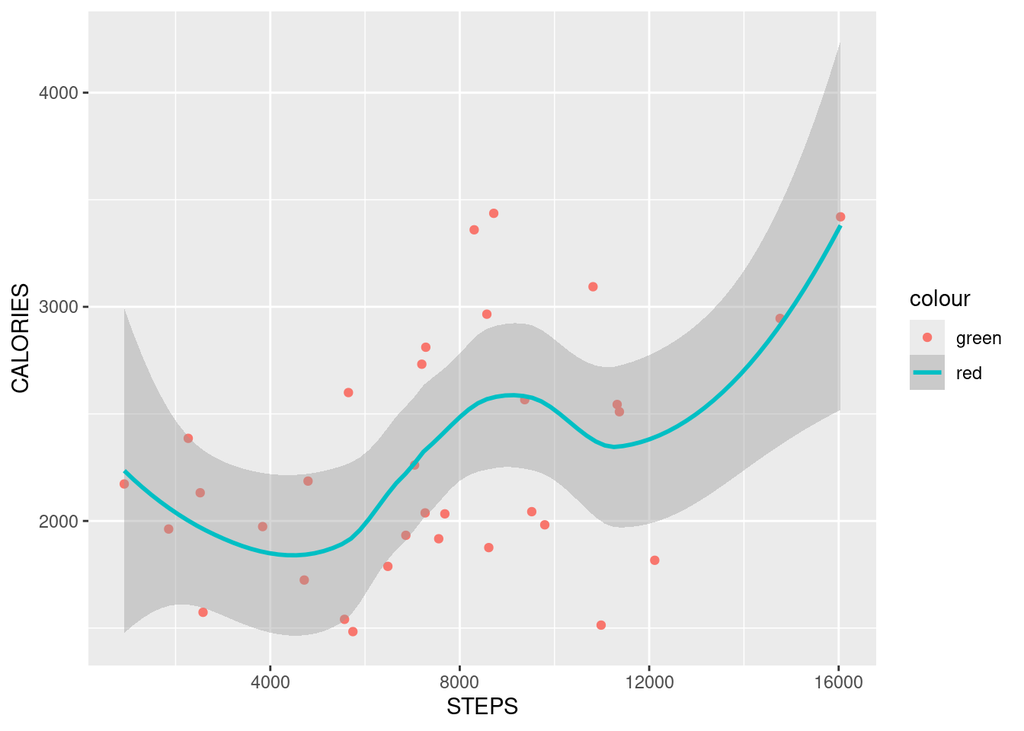

```r
ggplot(data = daily_activity_calc) +
  geom_point(mapping = aes(x = avg_step,y = avg_calories,color ="green"))+
  geom_smooth(mapping = aes(x = avg_step,y = avg_calories ,color ="red"))+
  labs(tile ="AVERAGE STEPS VS AVERAGE CALORIES",x = "STEPS",y = "CALORIES")
```

### This show a positive correlation the more steps the more calories burnt,the data is small make it difficult to get a causation

##5.2 Plotting relationship between activity minute and calories

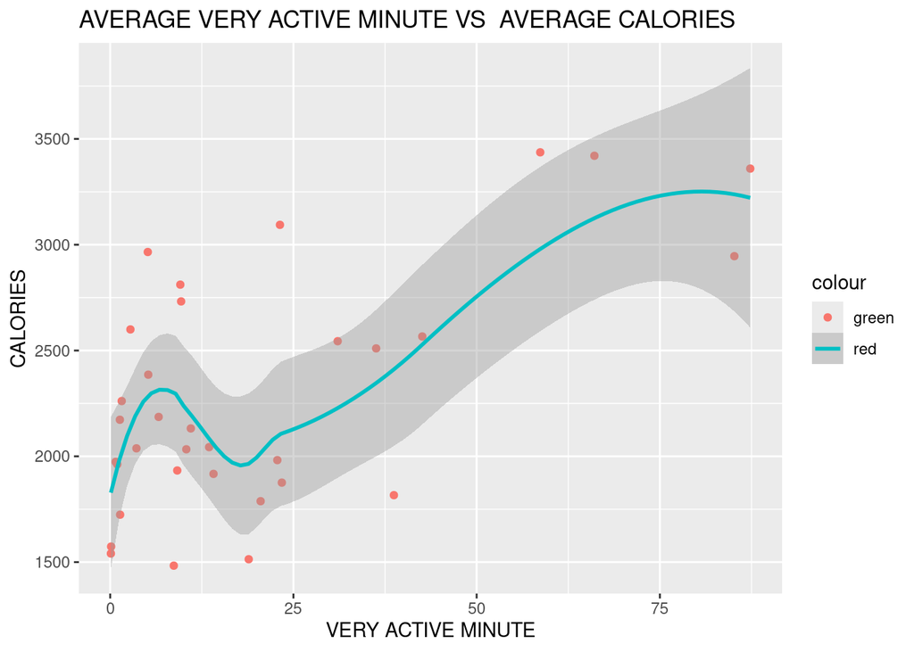

```r
ggplot(data = daily_activity_calc)+
  geom_point(mapping = aes(x =avg_very_active_min,y =avg_calories,color="green"))+
  geom_smooth(mapping = aes(x =avg_very_active_min,y=avg_calories,color="red"))+
  labs(title ="AVERAGE VERY ACTIVE MINUTE VS  AVERAGE CALORIES", x ="VERY ACTIVE MINUTE",y ="CALORIES")
```

###This shows that the more active the users are the more calories burn

##5.3 Plotting relationship between sedentary minute and calories

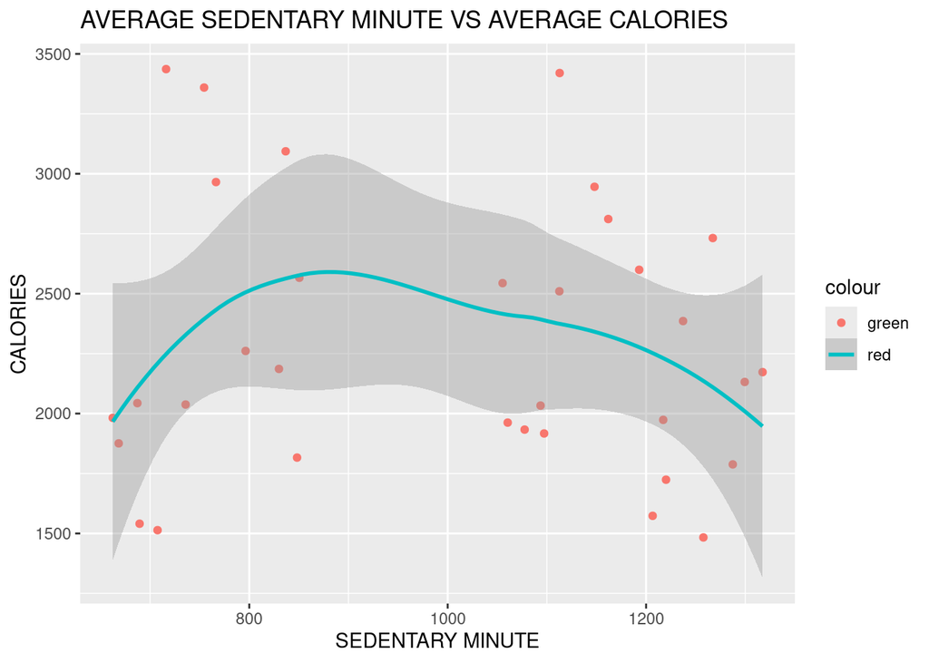

```r
ggplot(data=daily_activity_calc)+
  geom_point(mapping = aes(x=avg_sedentary_min,y=avg_calories,color="green"))+
  geom_smooth(mapping = aes(x=avg_sedentary_min,y=avg_calories,color="red"))+
  labs(title="AVERAGE SEDENTARY MINUTE VS AVERAGE CALORIES",x="SEDENTARY MINUTE",y="CALORIES")
```

###This shows that less activity minute results to less calories burn

##5.4 Plotting relationship between sleep and steps

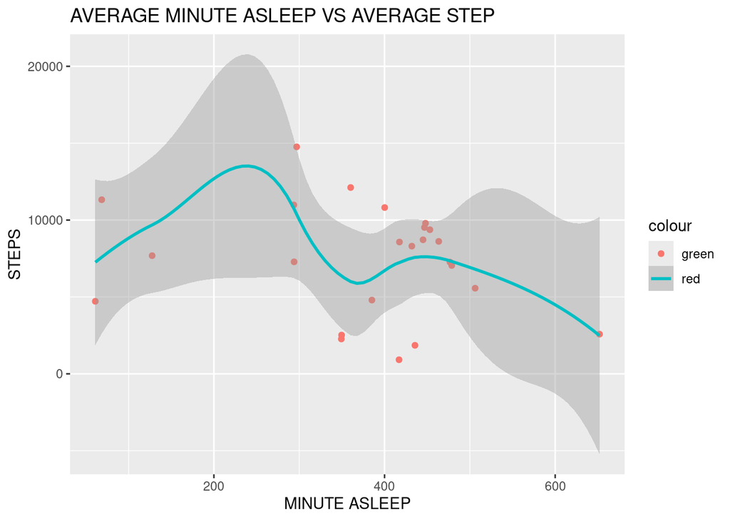

```r
ggplot(merged_activity_sleep)+
  geom_point(mapping=aes(x=avg_min_asleep,y=avg_step,color="green"))+
  geom_smooth(mapping=aes(x=avg_min_asleep,,y=avg_step,color="red"))+
  labs(title="AVERAGE MINUTE ASLEEP VS AVERAGE STEP",x ="MINUTE ASLEEP",y="STEPS")
```

##5.5 According to the recommended step by world health organization,plotting a chart to see number of users that meet up with the recommended daily step target

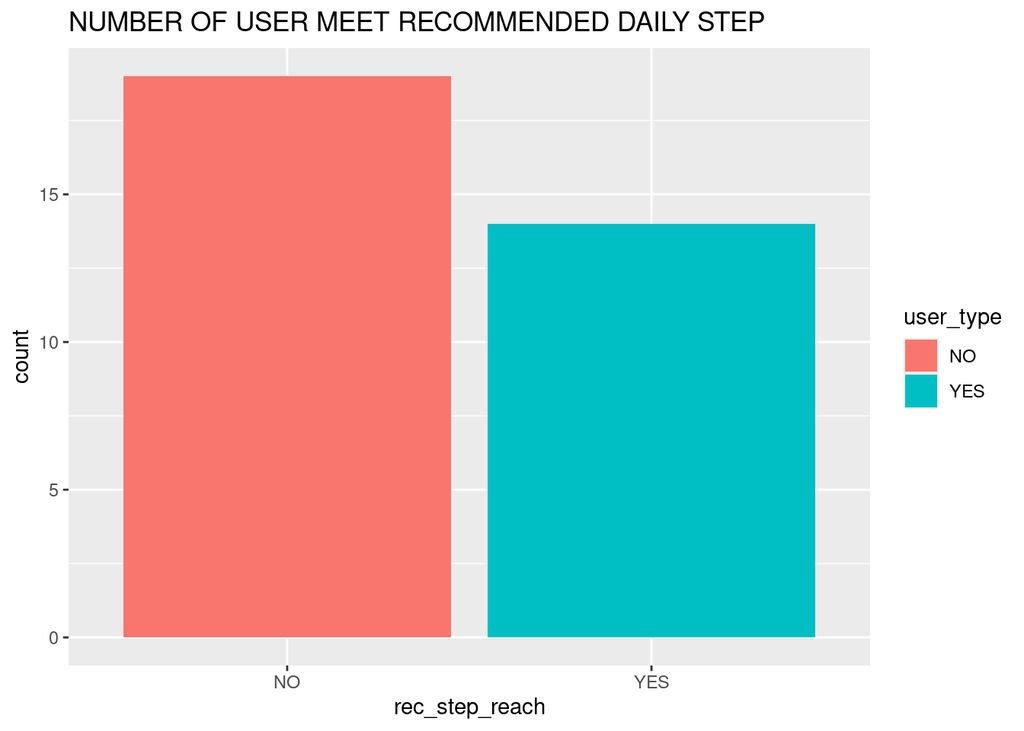

```r
ggplot(data_by_recommeded_step)+
  geom_bar(mapping = aes(x=user_type,fill=user_type))+
  labs(title = "NUMBER OF USER MEET RECOMMENDED DAILY STEP",x="rec_step_reach")
```

### This shows that 19 users did not meet up with the daily recommended steps and only 14 users meet up with the recommended steps

##5.6 According to the american health association,plotting a chart to see the number of users that meet up with with the recommended activity minutes

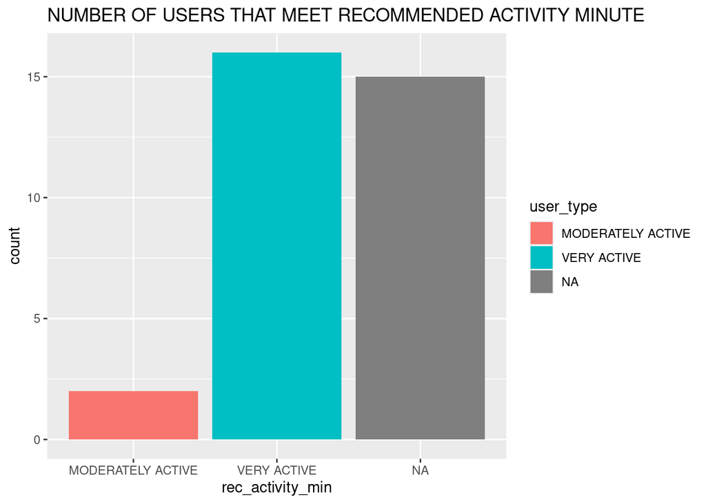

```r
ggplot(data_by_recommended_activity)+
  geom_bar(mapping = aes(x=user_type,fill=user_type))+
  labs(title = "NUMBER OF USERS THAT MEET RECOMMENDED ACTIVITY MINUTE",x= "rec_activity_min")
```

###The plot shows that above 15 are active active, less than 5 users are moderately active and more than 10 users those not meet any of the two recommended minute which make them sedentary ## Note: The NA means those that does not meet the recommended activity minute

##6.0 CONCLUSIONS AND RECOMMENDATION

*1. Based on the positive corelation between step taken and calories burn, i recommend bellebeat to make the smart watch notification to inform users daily steps to achieve their health goals

*3. Based on activity minutes of users,bellebeat can implement inbuilt pop up activity and stating the number of calories burn for each activity to help and motivate users to want to do them and help them reach their desire weight or maintain their weight and get fit.